# Loans with Duration

Art Steinmetz

#Examine properties of loans with duration

NOTE: This is not a trading strategy. It is an analysis of fundamental portfolio properties. As such we are not concerned with transaction costs or specific securities. The question we will answer is akin to the question “What does adding bonds do to the risk and reward of a stock index portfolio?” Transaction costs are not that relevant to the question. In practice, rolling Treasury futures or interest-rate swaps would entail ongoing trading costs but these are highly liquid markets with de-minimus bid-offer spreads.

```r
library(PerformanceAnalytics)
library(xts)
library(stringr)
library(tidyverse)
library(broom)
library(tidyquant)
library(Rblpapi)
library(timetk)
source("utilities.r") # tidy_bdh(), chart_cum_returns()
```

```r
tidy_chart_drawdowns<-function(r,shape=c('narrow','wide')){ #columns of name, date and return
  #returns a ggplot2 line chart object for plotting or further annotation
  shape=match.arg(shape)
  if (shape=='narrow'){
    xts_r<- r %>%
      select(name,date,return) %>%
      spread(name,return) %>%
      tk_xts(date_var=date,silent = TRUE)
  } else{
    xts_r<- r %>%
      tk_xts(date_var=date,silent = TRUE)
  }

  #pull out date as apply will lose it
  dd_date<-time(xts_r)

  gg<-xts_r %>%apply(2,DrawdownPeak) %>%
    as_tibble() %>%
    mutate(date=dd_date) %>% #put date back
    gather(name,drawdown,-date) %>%
    group_by(name) %>%
    ggplot(aes(x=date,y=drawdown,color=name))+geom_line()

  return(gg)
}
#---------------------------------------------------------------------
indices<-c("LBUSTRUU Index",
           "JPMTUS Index",
           "SPBDAL Index",
           "CSLLLTOT Index",
           'LF98TRUU Index',
           "USC0TR03 Index",
           "US0003M Index")
index_names<-c("BarcAgg",
               "Tsy",
               "SPLoan",
               "Loans",
               "BarcHY",
               "LIBOR3m_ret",
               "LIBOR3m_rate")
funds<-c("BKLN Equity",
         "HYG Equity",
         "OOSAX Equity")
fund_names<-c("Loan ETF",
              "HY Bond ETF",
              "Opp SFR")
common_names<-tibble(ticker=c(indices,funds),name=c(index_names,fund_names)) %>%
  mutate(ticker=word(ticker))
#some constants
OPTS_DAILY = c("periodicitySelection"="DAILY")
OPTS_MONTHLY = c("periodicitySelection"="MONTHLY")
START_DATE<- as.Date("1990-01-01")
FIELDS_NDX="LAST_PRICE"
FIELDS_FUNDS='DAY_TO_DAY_TOT_RETURN_GROSS_DVDS'
#to simulate a "loans plus" portfolio
LEVG_FACTOR = 1.2
HY_ALLOC =0.1
```

```r
#get bbgdata
if (!file.exists("data/loan_dur_data_raw.rdata")){
raw_ret_data_ndx<-tidy_bdh(secs=indices,
                           fields=FIELDS_NDX,
                           options=OPTS_MONTHLY,
                           start.date=START_DATE)
#since we are getting monthly data from different sources, month end data might be inconsistent.
#force consistancy with yearmon class
raw_ret_data_ndx<-raw_ret_data_ndx %>%
  mutate(date=date %>%
           as.yearmon(date) %>%
           as.Date(frac=1))

} else {
  load("data/loan_dur_data_raw.rdata")
}
```

```r
#create return series
#except where LAST_PRICE is a rate not a price, then compute with monthly compounding
ret_data_ndx<-raw_ret_data_ndx %>%
  group_by(ticker) %>%
  mutate(return=if_else(ticker=="US0003M",(1+LAST_PRICE/1200)-1,LAST_PRICE/lag(LAST_PRICE)-1))
  # below is the right way to convert a rate to a monthly return but simple compounding comes closer
  # to the BBG return series.
  #  mutate(return=if_else(ticker=="US0003M",((1+LAST_PRICE/100))^(1/12)-1,LAST_PRICE/lag(LAST_PRICE)-1))
#add common names
ret_data_ndx<-ret_data_ndx %>%
  ungroup() %>%
  left_join(common_names) %>%
  group_by(name)
```

The CS loan index series is longer than the SP series. Can we use it? Close enough.

```r
#show earliest
first_obs<-ret_data_ndx %>% summarise(earliest=min(date),n=n())
first_obs
```

| name | earliest | n |
| --- | --- | --- |
| BarcAgg | 1990-01-31 | 330 |
| BarcHY | 1990-01-31 | 330 |
| LIBOR3m_rate | 1990-01-31 | 330 |
| LIBOR3m_ret | 1995-12-31 | 259 |
| Loans | 1991-12-31 | 307 |
| SPLoan | 1996-12-31 | 247 |
| Tsy | 1990-01-31 | 330 |

SPDBAL has shorter history than CSLLLTOT. Can we use the latter?

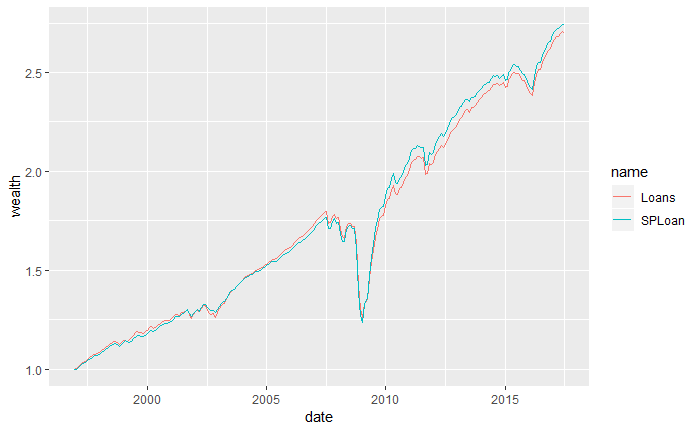

```r
earliest<-ret_data_ndx %>%
  filter(ticker=='SPBDAL') %>%
  ungroup() %>%
  summarize(min(date)) %>%
  pull(1)
ret_data_ndx %>%
  filter(ticker=="CSLLLTOT" | ticker=="SPBDAL",date>earliest-1) %>%
  chart_cum_returns()
```

The LIBOR rate series is longer than the LIBOR index series. Can we use it? The discrepency is a bit wide. I prefer the return series so I chain the rate series just for the earlier dates.

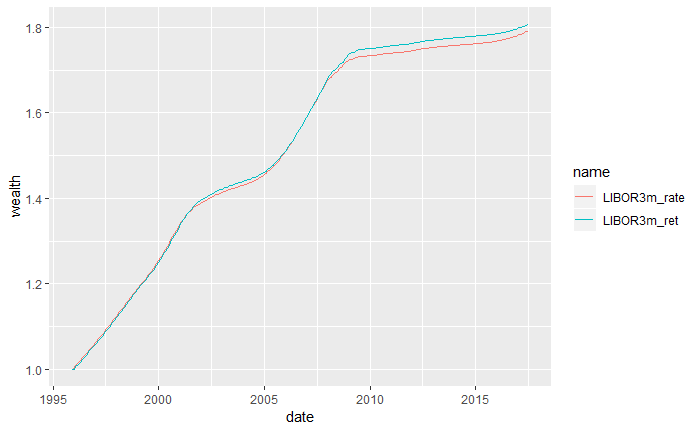

```r
earliest<-ret_data_ndx %>%
  filter(name=='LIBOR3m_ret') %>%
  ungroup() %>%
  summarize(min(date)) %>%
  pull(1)
ret_data_ndx %>%
  filter(name %in% c("LIBOR3m_rate","LIBOR3m_ret"),date>earliest-1) %>%
  chart_cum_returns()
```

```r
#create blended portfolios.
#a portfolio of treasuries minus libor 1month carry
# we go back to wide to make it easier to mutate columns
r<-ret_data_ndx %>%
  select(date,name,return) %>%
  spread(name,return)
#pad missing LIBOR with monthly return computed from rate
r<-r %>% mutate(LIBOR3m_ret=if_else(is.na(LIBOR3m_ret),LIBOR3m_rate,LIBOR3m_ret))
# consolidate LIBOR
r<-r %>% select(-LIBOR3m_rate,-SPLoan) %>% rename(LIBOR3m=LIBOR3m_ret)
# remove dates where we can't make a simulated portfolio
r<-r %>% filter(!is.na(Loans))
#create simulated portfolio returns
r<-r %>% mutate(levg_tsy=Tsy-LIBOR3m)
r<-r %>% mutate(Loans_w_Dur=Loans+levg_tsy)
r<-r %>% mutate(Loans_plus= ((1-HY_ALLOC)*Loans+HY_ALLOC*BarcHY)*LEVG_FACTOR - LIBOR3m*(LEVG_FACTOR-1))
r<-r %>% mutate(HY_wo_Dur=BarcHY-levg_tsy)
r<-r %>% mutate(HY_w_Dur=BarcHY+levg_tsy)
# r is for CAPM return analytics data_ndx is for graphing wealth
data_ndx <-r %>%
  gather(name,return,-date) %>%
  group_by(name)
```

#Theretical Foundation Orthogonal return factors, both with positive risk premia.

How are Loans related to Treasuries?

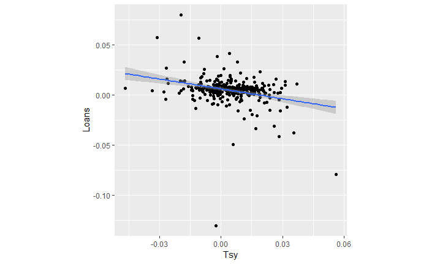

```r
gg<-r %>% ggplot(aes(x=Tsy,y=Loans))+geom_point()+geom_smooth(method="lm")
gg<-gg+theme(aspect.ratio=1)
gg
```

```r
tidy(lm(Loans~Tsy,data=r))
```

| term | estimate | std.error | statistic | p.value |
| --- | --- | --- | --- | --- |
| (Intercept) | 0.006223338 | 0.0008455455 | 7.360146 | 1.728134e-12 |
| Tsy | -0.328304077 | 0.0614800359 | -5.340011 | 1.823226e-07 |

```r
glance(lm(Loans~Tsy,data=r))
```

| r.squared | adj.r.squared | sigma | statistic | p.value | df | logLik | AIC | BIC | deviance | df.residual |
| --- | --- | --- | --- | --- | --- | --- | --- | --- | --- | --- |
| 0.08575751 | 0.08275013 | 0.01398595 | 28.51572 | 1.823226e-07 | 2 | 873.3369 | -1740.674 | -1729.503 | 0.05946447 | 304 |

How are HY bonds related to Treasuries?

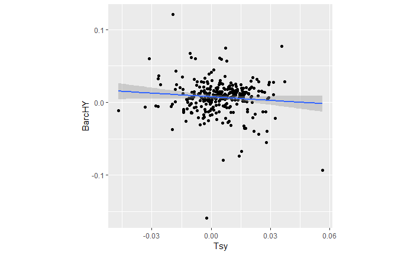

```r
gg<-r %>% ggplot(aes(x=Tsy,y=BarcHY))+geom_point()+geom_smooth(method="lm")
gg<-gg+theme(aspect.ratio=1)
gg
```

```r
tidy(lm(Loans~Tsy,data=r))
```

| term | estimate | std.error | statistic | p.value |
| --- | --- | --- | --- | --- |
| (Intercept) | 0.006223338 | 0.0008455455 | 7.360146 | 1.728134e-12 |
| Tsy | -0.328304077 | 0.0614800359 | -5.340011 | 1.823226e-07 |

```r
glance(lm(Loans~Tsy,data=r))
```

| r.squared | adj.r.squared | sigma | statistic | p.value | df | logLik | AIC | BIC | deviance | df.residual |
| --- | --- | --- | --- | --- | --- | --- | --- | --- | --- | --- |
| 0.08575751 | 0.08275013 | 0.01398595 | 28.51572 | 1.823226e-07 | 2 | 873.3369 | -1740.674 | -1729.503 | 0.05946447 | 304 |

Return analysis

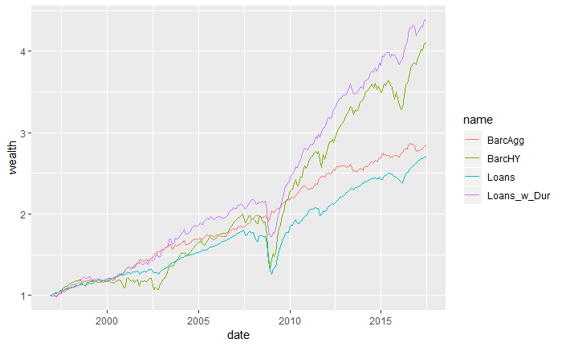

```r
data_ndx %>%
  filter(date>as.Date("1996-12-30")) %>%
  filter(name %in% c("BarcAgg","BarcHY","Loans","Loans_w_Dur")) %>%
  chart_cum_returns()
```

#Performance during recent rise in interest rates.

After the 2016 election rates spiked up for a time. How did Loans-with-Duration perform?

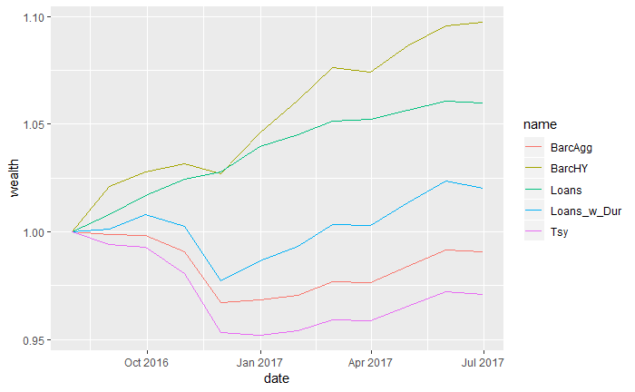

```r
data_ndx %>%
  filter(date>as.Date("2016-08-30")) %>%
  filter(name %in% c("Loans","Loans_w_Dur","BarcAgg", "Tsy","BarcHY")) %>%
  chart_cum_returns()
```

#Inverted Yield Curve Period Yield Curve was flat to inverted from late 1997 to early 2001. Negative carry hurt the portfolio but falling rates (which typically follow such periods) boosted the portfolio coming out of it.

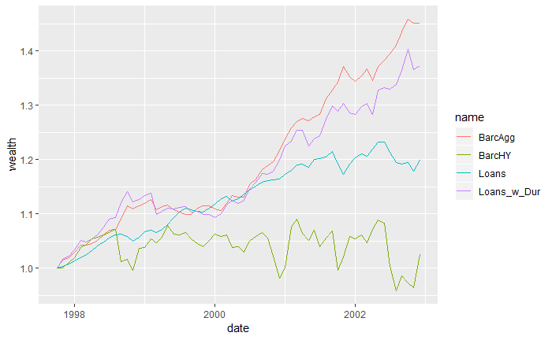

```r
data_ndx %>%
  filter(date>as.Date("1997-09-30")) %>%
  filter(date<as.Date("2002-12-30")) %>%
  filter(name %in% c("BarcAgg","BarcHY","Loans","Loans_w_Dur")) %>%
  chart_cum_returns()
```

Drawdown analysis

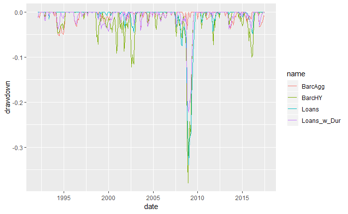

```r
r %>%
  select(date, BarcAgg,BarcHY,Loans_w_Dur,Loans) %>%
  tidy_chart_drawdowns(shape='wide')
```

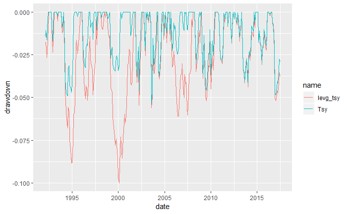

```r
r %>%
  select(date, Tsy,levg_tsy) %>%
  tidy_chart_drawdowns(shape='wide')
```

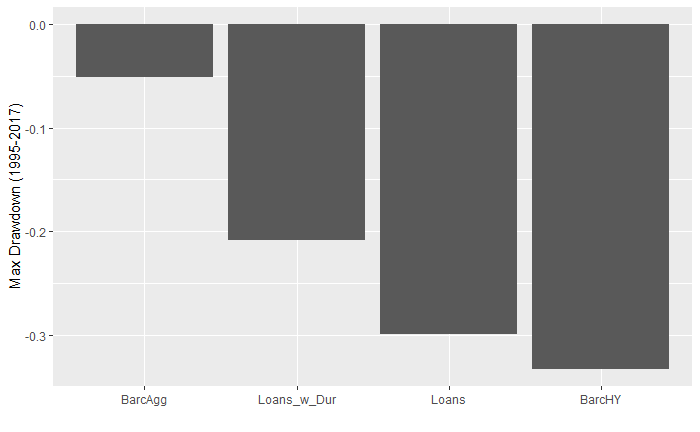

```r
temp <-r %>%
  select(date, BarcAgg,BarcHY,Loans_w_Dur,Loans) %>%
  gather(name,return,-date) %>% group_by(name)
gg<-temp %>%
  tq_performance(return,performance_fun = maxDrawdown) %>%
  arrange(maxDrawdown.1) %>%
  ggplot(aes(x=reorder(name,maxDrawdown.1),y=-maxDrawdown.1))+geom_col()
gg<-gg+labs(x='',y='Max Drawdown (1995-2017)')
gg
```

```r
#table.AnnualizedReturns(r)
```

```r
drawdownSummary<-function(dat){
  dd<-NULL
  for (n in 1:ncol(dat)) {
    d<-findDrawdowns(dat[,n])$length
    a<-findDrawdowns(dat[,n])$return


    dd<-bind_rows(dd,data_frame(name=names(dat[,n]),
                                  Frequency=length(d),
                                  AvgMonths=round(mean(d),2),
                                  AvgDrawPct=round(100*mean(a),2),
                                  MaxDrawPct=round(100*min(a),2)
                                  )
              )
  }
  return(dd)
}
drawdownSummary(tk_xts(r,date_var = date)) %>% arrange(MaxDrawPct) %>% filter(name != 'LIBOR3m')
```

```
Non-numeric columns being dropped: date`data_frame()` is deprecated, use `tibble()`.
```

| name | Frequency | AvgMonths | AvgDrawPct | MaxDrawPct |
| --- | --- | --- | --- | --- |
| HY_wo_Dur | 71 | 5.31 | -1.88 | -41.21 |
| Loans_plus | 52 | 6.88 | -1.43 | -35.48 |
| BarcHY | 57 | 6.37 | -1.95 | -33.31 |
| Loans | 42 | 8.29 | -1.38 | -29.94 |
| HY_w_Dur | 76 | 5.03 | -1.88 | -28.14 |
| Loans_w_Dur | 91 | 4.36 | -0.92 | -20.91 |
| levg_tsy | 47 | 7.51 | -1.69 | -9.59 |
| Tsy | 79 | 4.87 | -0.94 | -5.34 |
| BarcAgg | 75 | 5.08 | -0.72 | -5.15 |

```r
r_xts <- tk_xts(r,date_var = date)
```

```
Non-numeric columns being dropped: date
```

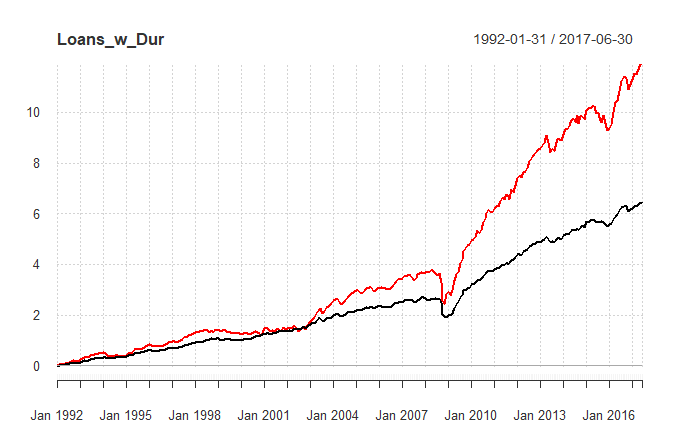

```r
chart.CumReturns(r_xts[,c('Loans_w_Dur','HY_w_Dur')])
```

```r
table.CAPM(Ra=r_xts,Rb=r_xts$BarcAgg,Rf=r_xts$LIBOR3m)
```

```
essentially perfect fit: summary may be unreliablethe standard deviation is zero
```

|  | BarcAgg to BarcAgg | BarcHY to BarcAgg | LIBOR3m to BarcAgg | Loans to BarcAgg | Tsy to BarcAgg | levg_tsy to BarcAgg | Loans_w_Dur to BarcAgg | Loans_plus to BarcAgg | HY_wo_Dur to BarcAgg | HY_w_Dur to BarcAgg |
| --- | --- | --- | --- | --- | --- | --- | --- | --- | --- | --- |
| Alpha | 0.0000 | 0.0031 | 0.0000 | 0.0022 | -0.0005 | -0.0030 | 0.0017 | 0.0028 | 0.0035 | 0.0026 |
| Beta | 1.0000 | 0.5688 | 0.0000 | 0.0078 | 1.1591 | 1.1691 | 1.1669 | 0.0766 | -0.5903 | 1.7279 |
| Beta+ | 1.0000 | 0.0974 | 0.0000 | -0.5077 | 1.2869 | 1.2818 | 0.7792 | -0.5367 | -1.1896 | 1.3843 |
| Beta- | 1.0000 | 1.1218 | 0.0000 | 0.4846 | 1.0304 | 1.0536 | 1.5150 | 0.6580 | 0.0915 | 2.1522 |
| R-squared | 1.0000 | 0.0573 | NaN | 0.0000 | 0.8483 | 0.8433 | 0.5062 | 0.0018 | 0.0454 | 0.4408 |
| Annualized Alpha | 0.0000 | 0.0375 | 0.0000 | 0.0269 | -0.0056 | -0.0356 | 0.0211 | 0.0336 | 0.0434 | 0.0317 |
| Correlation | 1.0000 | 0.2395 | NA | 0.0053 | 0.9210 | 0.9183 | 0.7114 | 0.0427 | -0.2130 | 0.6639 |
| Correlation p-value | 0.0000 | 0.0000 | NA | 0.9259 | 0.0000 | 0.0000 | 0.0000 | 0.4569 | 0.0002 | 0.0000 |
| Tracking Error | 0.0000 | 0.0832 | 0.0355 | 0.0625 | 0.0183 | 0.0189 | 0.0413 | 0.0716 | 0.1114 | 0.0737 |
| Active Premium | 0.0000 | 0.0247 | -0.0254 | 0.0010 | -0.0022 | -0.0335 | 0.0255 | 0.0090 | -0.0015 | 0.0493 |

[output cut: 2 more lines]

```r
SharpeRatio.annualized(r_xts,Rf=r_xts$LIBOR3m,scale=12)
```

```
                                  BarcAgg    BarcHY LIBOR3m     Loans       Tsy   levg_tsy Loans_w_Dur
Annualized Sharpe Ratio (Rf=3%) 0.6911549 0.5830721       0 0.5072612 0.5014242 -0.1773737   0.8641839
                                Loans_plus HY_wo_Dur  HY_w_Dur
Annualized Sharpe Ratio (Rf=3%)  0.5339783 0.2369601 0.7929161
```